# Homework #5-

Andrea Astudillo

2024-10-19

#1 Create a times series

```r
flightVolume = read.csv(file.choose())
library(readr)
library(fpp)
library(fpp2)
library(TTR)
flight=(flightVolume)
flight_ts=ts(flightVolume$reslong, frequency = 12, start = c(1976,1), end = c(2016,11))
```

#2 Verify how much history to include in your analysis

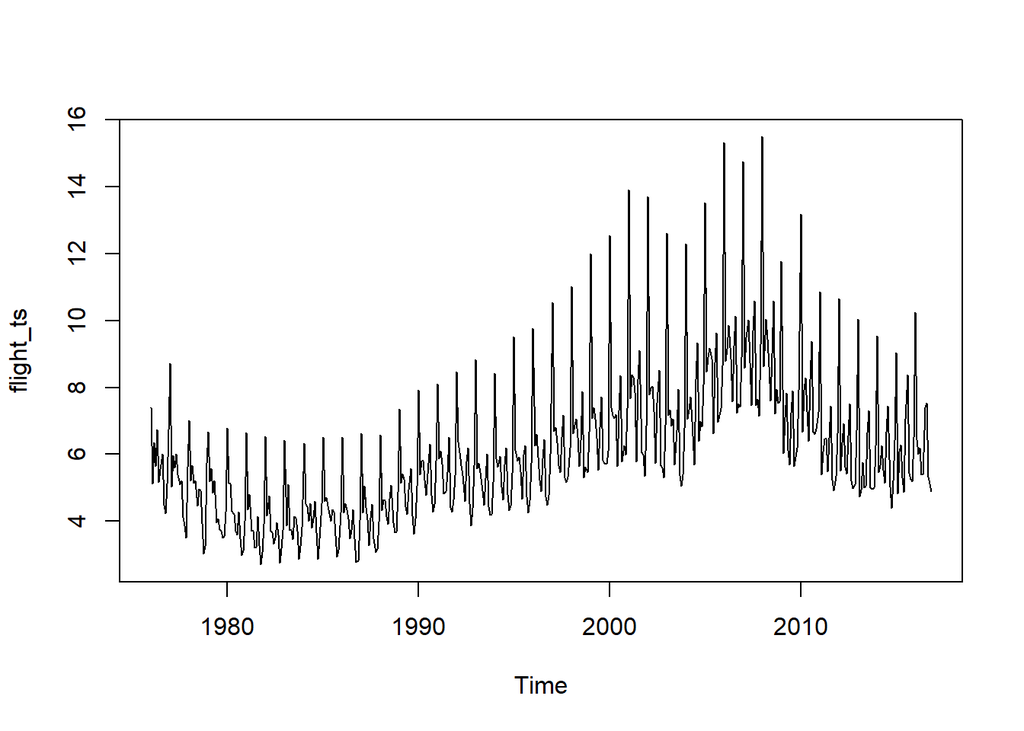

```r
plot(flight_ts)
```

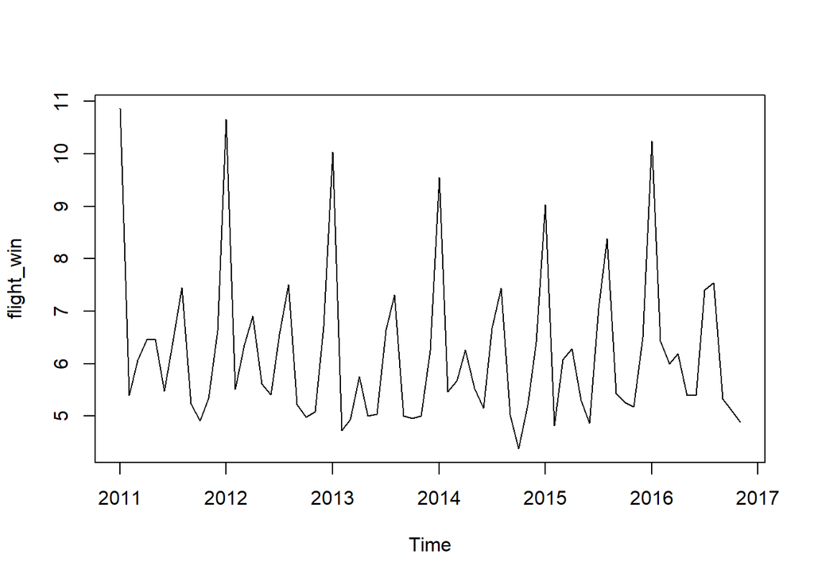

```r
flight_win=window(flight_ts, start=c(2011,1), end = c(2016,11))
plot(flight_win)
```

#3-Hypothesize if the dataset has trend, seasonality, or both

I hypothesis that the data set will have both seasonality and trend

#4 Verify using Acf

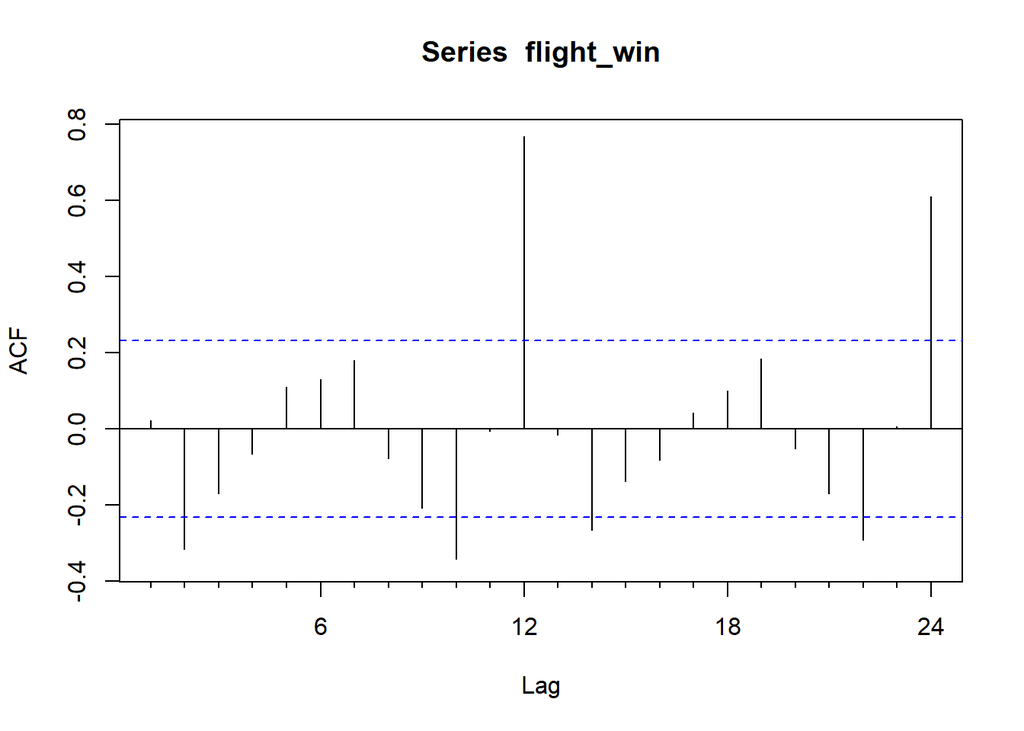

```r
Acf(flight_win)
```

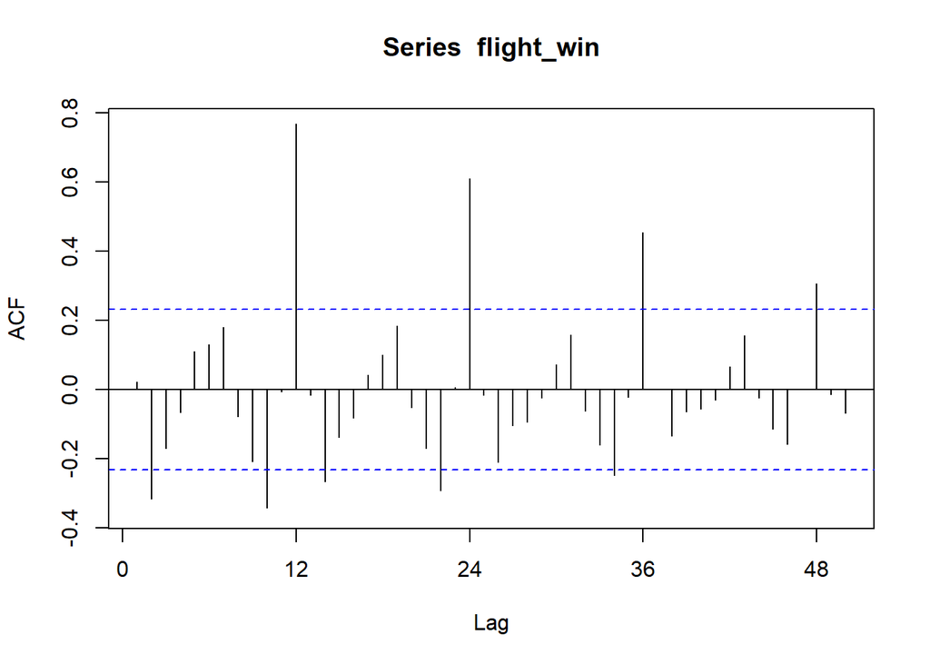

```r
Acf(flight_win,lag.max = 50)
```

#5 Verify using decomposition

The decomposition plot verifies what was explained in the Acf plot. The data contains seasonality and trends.

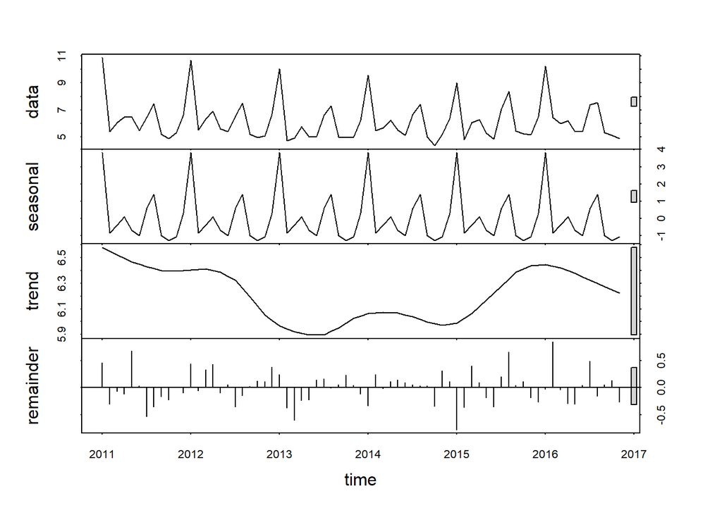

```r
stl_decomp = stl(flight_win,s.window = "periodic")
plot(stl_decomp)
```

#6 Create a forecast model for the next 12 months. Include Naive, Average, Exponential Smoothing, HoltWinters, and Decomposition (both types).

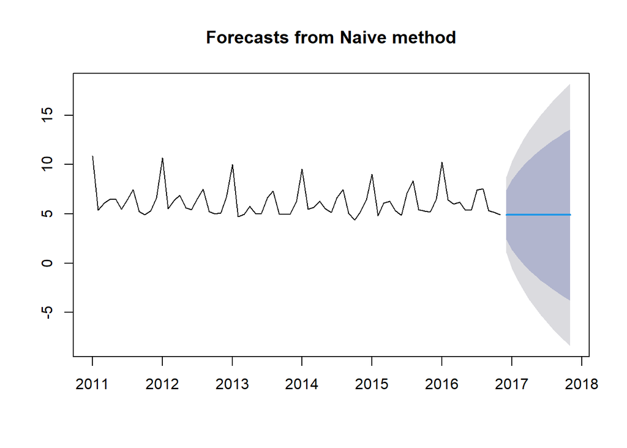

```r
naive_flight=naive(flight_win,12)
forecast_naive=forecast(naive_flight, h=12)
plot(forecast_naive)
```

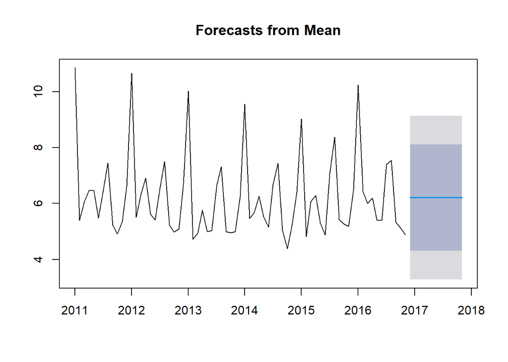

```r
mean_flight=meanf(flight_win, 12)
forecast_mean=forecast(mean_flight, h=12)
plot(forecast_mean)
```

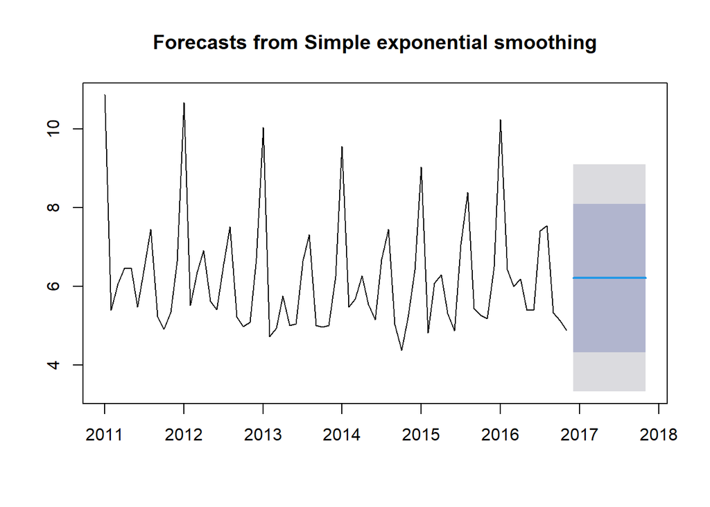

```r
SS_flight=ses(flight_win, 12)
forecast_SS=forecast(SS_flight, h=12)
plot(forecast_SS)
```

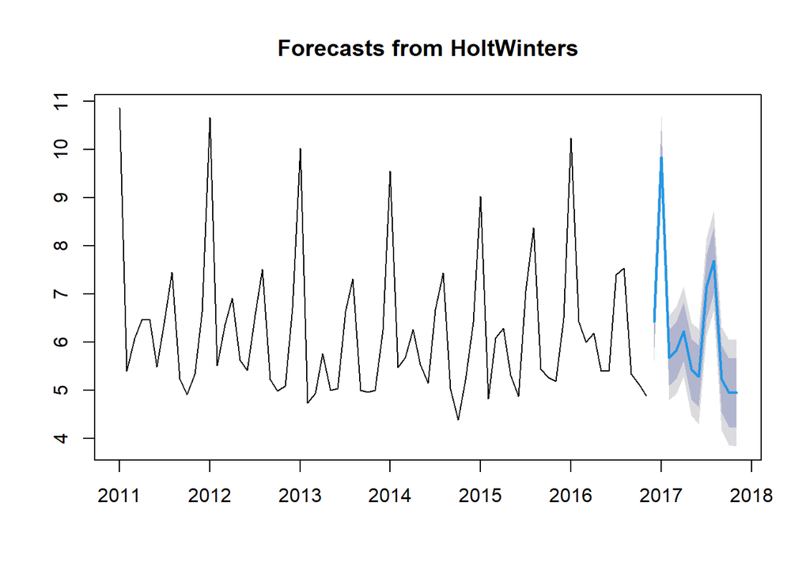

```r
HW_flight=HoltWinters(flight_win)
forecast_HW=forecast(HW_flight, h=12)
plot(forecast_HW)
```

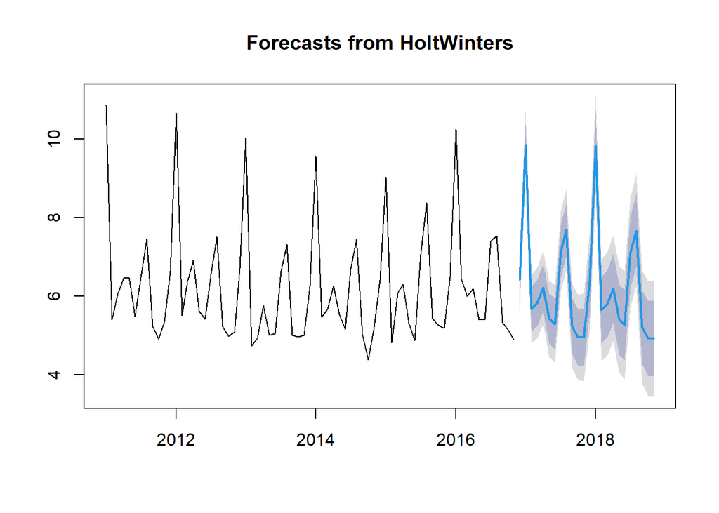

```r
decompose_flight_additive=decompose(flight_win)
additive_flight=HoltWinters(flight_win, seasonal = "additive")
forecast_additive_flight=forecast(additive_flight)
plot(forecast_additive_flight)
```

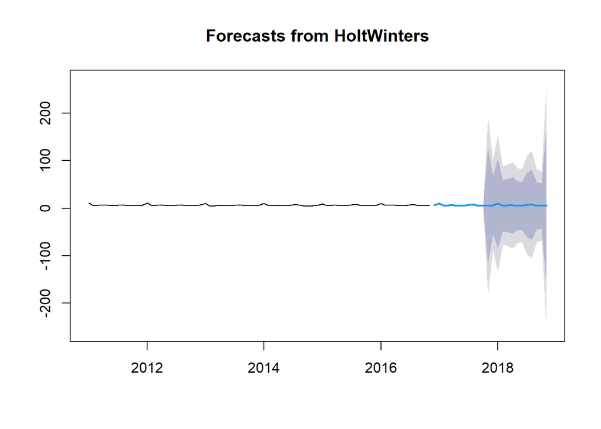

```r
decompose_flight_multiplicative=decompose(flight_win, type = "multiplicative")
multiplicative_flight=HoltWinters(flight_win, seasonal = "multiplicative")
forecast_multiplicative_flight=forecast(multiplicative_flight)
plot(forecast_multiplicative_flight)
```

#7 ChoOse an accuracy measure

Given the results of the accuracy metrics in the naive forecast, it does not appear to perform well across all of them.

The accuracy metrics in the mean forecast appears to be performing better than the previous one. ME is close to zero indicating less errors in the forecast.

The holt-winters is performing well across all metrics.

```r
naive_accuracy=accuracy(forecast_naive)
naive_accuracy
```

```
##                       ME     RMSE      MAE       MPE     MAPE     MASE
## Training set -0.08528571 1.959619 1.381571 -5.362836 22.48167 3.547116
##                    ACF1
## Training set -0.2616306
```

```r
mean_accuracy=accuracy(forecast_mean)
mean_accuracy
```

```
##                        ME     RMSE      MAE       MPE     MAPE     MASE
## Training set 3.754699e-17 1.450101 1.075937 -4.394771 16.68293 2.762415
##                    ACF1
## Training set 0.02151778
```

```r
SS_accuracy=accuracy(forecast_SS)
SS_accuracy
```

```
##                         ME     RMSE      MAE       MPE    MAPE   MASE
## Training set -0.0003053281 1.450173 1.076048 -4.400122 16.6855 2.7627
##                    ACF1
## Training set 0.02151185
```

```r
HW_accuracy=accuracy(forecast_HW)
HW_accuracy
```

```
##                        ME      RMSE       MAE        MPE     MAPE      MASE
## Training set -0.002111296 0.4107877 0.3054468 -0.1476035 4.976695 0.7842193
##                  ACF1
## Training set 0.230955
```

#8 Show model rank with accuracy measures

```r
table_accuracy=data.frame(Method=c("Naive", "Mean", "Exponential Smoothing", "Holt-Winters"), ME=c(naive_accuracy[1,"ME"], mean_accuracy[1,"ME"], SS_accuracy[1,"ME"], HW_accuracy[1,"ME"]), RMSE=c(naive_accuracy[1,"RMSE"], mean_accuracy[1,"RMSE"], SS_accuracy[1,"RMSE"], HW_accuracy[1,"RMSE"]), MAE=c(naive_accuracy[1,"MAE"], mean_accuracy[1,"MAE"], SS_accuracy[1,"MAE"], HW_accuracy[1,"MAE"]), MAPE=c(naive_accuracy[1,"MAPE"], mean_accuracy[1,"MAPE"], SS_accuracy[1,"MAPE"], HW_accuracy[1,"MAPE"]), MASE=c(naive_accuracy[1,"MASE"], mean_accuracy[1,"MASE"], SS_accuracy[1,"MASE"], HW_accuracy[1,"MASE"]))
print(table_accuracy)
```

```
##                  Method            ME      RMSE       MAE      MAPE      MASE
## 1                 Naive -8.528571e-02 1.9596191 1.3815714 22.481668 3.5471155
## 2                  Mean  3.754699e-17 1.4501010 1.0759373 16.682927 2.7624152
## 3 Exponential Smoothing -3.053281e-04 1.4501735 1.0760483 16.685500 2.7627003
## 4          Holt-Winters -2.111296e-03 0.4107877 0.3054468  4.976695 0.7842193
```

#9 Choose which models and how are you going to use them for Forecasting

#10 Provide the forecast for the next 12 months (point and range) and explain why you feel confident with these forecasts

```r
forecast_HW
```

```
##          Point Forecast    Lo 80     Hi 80    Lo 95     Hi 95
## Dec 2016       6.420937 5.889980  6.951895 5.608908  7.232967
## Jan 2017       9.842299 9.290305 10.394293 8.998097 10.686501
## Feb 2017       5.670556 5.098299  6.242813 4.795364  6.545748
## Mar 2017       5.832136 5.240308  6.423963 4.927014  6.737258
## Apr 2017       6.218089 5.607318  6.828860 5.283995  7.152182
## May 2017       5.433709 4.804565  6.062854 4.471516  6.395902
## Jun 2017       5.289261 4.642265  5.936257 4.299766  6.278756
## Jul 2017       7.143919 6.479551  7.808287 6.127856  8.159982
## Aug 2017       7.689649 7.008352  8.370947 6.647695  8.731604
## Sep 2017       5.241066 4.543250  5.938883 4.173849  6.308284
## Oct 2017       4.952241 4.238288  5.666194 3.860345  6.044138
## Nov 2017       4.947783 4.218050  5.677516 3.831753  6.063813
```

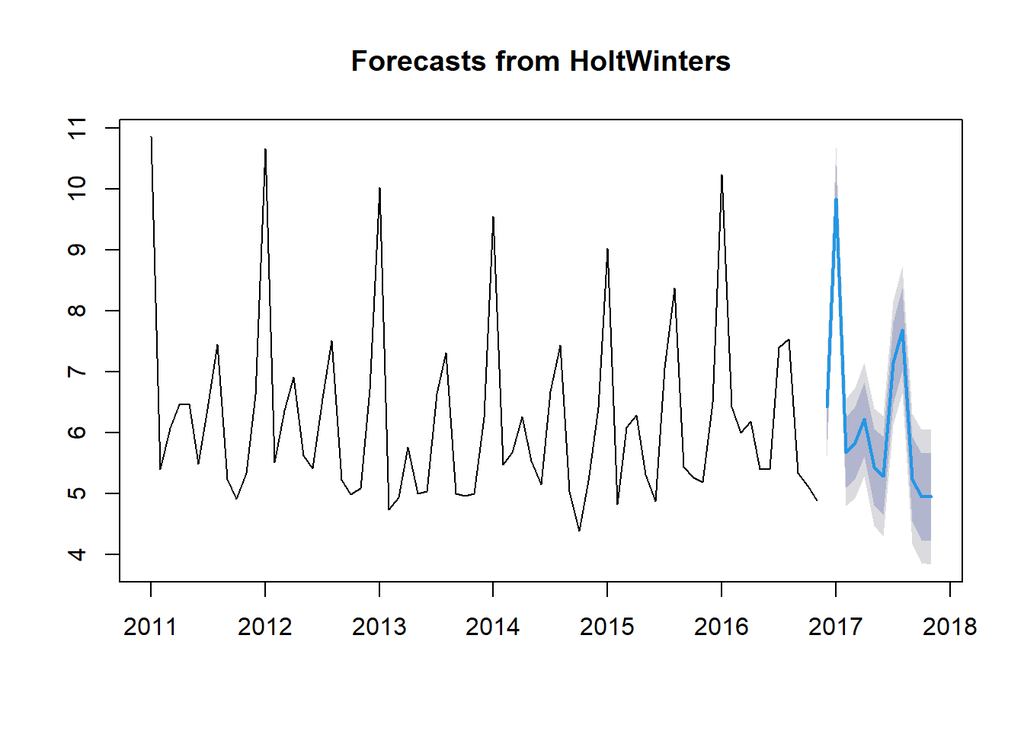

```r
plot(forecast_HW)
```

```r
attributes(forecast_HW)
```

```
## $names
##  [1] "method"    "model"     "level"     "mean"      "lower"     "upper"
##  [7] "x"         "series"    "fitted"    "residuals"
##
## $class
## [1] "forecast"
```

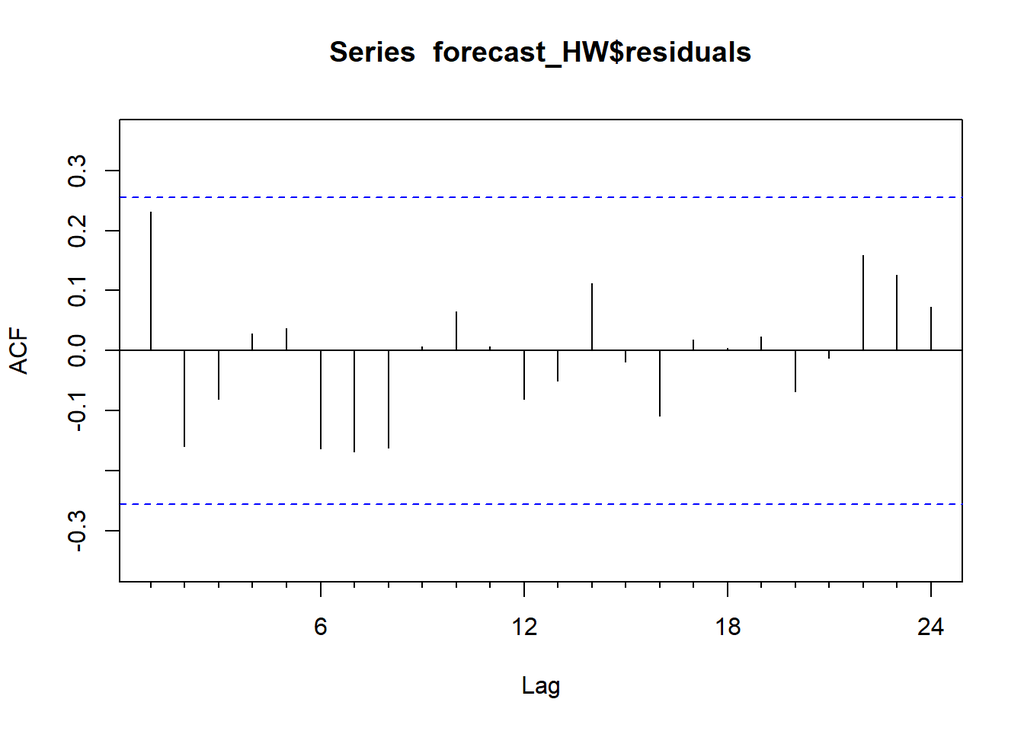

```r
Acf(forecast_HW$residuals)
```